# Hypertension and microbiome

Joonatan Palmu

01.02.2020

# 1 Importing libraries:

**Libraries**

```r
library(dplyr)
library(tibble)
library(phyloseq)
library(nortest)
library(microbiome)
library(knitr)
library(tidyr)
library(vegan)
library(reshape)
library(parallel)
library(officer)
library(flextable)
library(xtable)
library(rvg)
library(tableone)
library(scales)
library(ggplot2)
library(egg)
library(gridExtra)
library(png)
library(ggpubr)
library(broom)
library(ggfortify)
library(RColorBrewer)
library(gvlma)
library(purrr)
library(gtable)
library(car)
library(M3C)
library(emmeans)
library(DESeq2)
library(ggeffects)
library(pander)
library(hexbin)
```

# 2 Session info

**R version 3.6.0 (2019-04-26)**

**Platform:** x86_64-pc-linux-gnu (64-bit)

**locale:** *LC_CTYPE=en_US.utf8*, *LC_NUMERIC=C*, *LC_TIME=en_US.utf8*, *LC_COLLATE=en_US.utf8*, *LC_MONETARY=en_US.utf8*, *LC_MESSAGES=en_US.utf8*, *LC_PAPER=en_US.utf8*, *LC_NAME=C*, *LC_ADDRESS=C*, *LC_TELEPHONE=C*, *LC_MEASUREMENT=en_US.utf8* and *LC_IDENTIFICATION=C*

**attached base packages:** *stats4*, *parallel*, *stats*, *graphics*, *grDevices*, *utils*, *datasets*, *methods* and *base*

**other attached packages:** *hexbin(v.1.28.0)*, *pander(v.0.6.3)*, *ggeffects(v.0.12.0)*, *DESeq2(v.1.24.0)*, *SummarizedExperiment(v.1.14.1)*, *DelayedArray(v.0.10.0)*, *BiocParallel(v.1.18.1)*, *matrixStats(v.0.55.0)*, *GenomicRanges(v.1.36.1)*, *GenomeInfoDb(v.1.20.0)*, *IRanges(v.2.18.3)*, *S4Vectors(v.0.22.1)*, *emmeans(v.1.4.3.01)*, *M3C(v.1.6.0)*, *Biobase(v.2.44.0)*, *BiocGenerics(v.0.30.0)*, *car(v.3.0-3)*, *carData(v.3.0-2)*, *gtable(v.0.3.0)*, *purrr(v.0.3.2)*, *gvlma(v.1.0.0.3)*, *RColorBrewer(v.1.1-2)*, *ggfortify(v.0.4.7)*, *broom(v.0.5.2)*, *ggpubr(v.0.2.3)*, *magrittr(v.1.5)*, *png(v.0.1-7)*, *egg(v.0.4.5)*, *gridExtra(v.2.3)*, *scales(v.1.0.0)*, *tableone(v.0.10.0)*, *rvg(v.0.2.0)*, *xtable(v.1.8-4)*, *flextable(v.0.5.5)*, *officer(v.0.3.5)*, *reshape(v.0.8.8)*, *vegan(v.2.5-6)*, *lattice(v.0.20-38)*, *permute(v.0.9-5)*, *tidyr(v.1.0.0)*, *knitr(v.1.25)*, *microbiome(v.1.6.0)*, *ggplot2(v.3.2.1)*, *nortest(v.1.0-4)*, *phyloseq(v.1.28.0)*, *tibble(v.2.1.3)*, *dplyr(v.0.8.3)*, *rmarkdown(v.1.16)*, *R.utils(v.2.8.0)*, *R.oo(v.1.22.0)* and *R.methodsS3(v.1.7.1)*

**loaded via a namespace (and not attached):** *readxl(v.1.3.1)*, *uuid(v.0.1-2)*, *snow(v.0.4-3)*, *backports(v.1.1.5)*, *Hmisc(v.4.2-0)*, *NMF(v.0.21.0)*, *plyr(v.1.8.4)*, *igraph(v.1.2.4.1)*, *lazyeval(v.0.2.2)*, *splines(v.3.6.0)*, *sigclust(v.1.1.0)*, *gridBase(v.0.4-7)*, *digest(v.0.6.21)*, *foreach(v.1.4.7)*, *htmltools(v.0.3.6)*, *matrixcalc(v.1.0-3)*, *viridis(v.0.5.1)*, *memoise(v.1.1.0)*, *checkmate(v.1.9.4)*, *cluster(v.2.0.9)*, *doParallel(v.1.0.15)*, *openxlsx(v.4.1.0.1)*, *annotate(v.1.62.0)*, *Biostrings(v.2.52.0)*, *colorspace(v.1.4-1)*, *blob(v.1.2.0)*, *mitools(v.2.4)*, *haven(v.2.1.1)*, *xfun(v.0.10)*, *crayon(v.1.3.4)*, *RCurl(v.1.95-4.12)*, *jsonlite(v.1.6)*, *genefilter(v.1.66.0)*, *zeallot(v.0.1.0)*, *survival(v.2.44-1.1)*, *iterators(v.1.0.12)*, *ape(v.5.3)*, *glue(v.1.3.1)*, *registry(v.0.5-1)*, *zlibbioc(v.1.30.0)*, *XVector(v.0.24.0)*, *sjmisc(v.2.8.2)*, *Rhdf5lib(v.1.6.1)*, *abind(v.1.4-5)*, *mvtnorm(v.1.0-11)*, *DBI(v.1.0.0)*, *rngtools(v.1.4)*, *bibtex(v.0.4.2)*, *Rcpp(v.1.0.2)*, *htmlTable(v.1.13.2)*, *viridisLite(v.0.3.0)*, *bit(v.1.1-14)*, *foreign(v.0.8-71)*, *Formula(v.1.2-3)*, *survey(v.3.36)*, *htmlwidgets(v.1.3)*, *acepack(v.1.4.1)*, *XML(v.3.98-1.20)*, *pkgconfig(v.2.0.3)*, *nnet(v.7.3-12)*, *locfit(v.1.5-9.1)*, *AnnotationDbi(v.1.46.1)*, *tidyselect(v.0.2.5)*, *rlang(v.0.4.0)*, *reshape2(v.1.4.3)*, *munsell(v.0.5.0)*, *cellranger(v.1.1.0)*, *tools(v.3.6.0)*, *RSQLite(v.2.1.1)*, *generics(v.0.0.2)*, *sjlabelled(v.1.1.1)*, *ade4(v.1.7-13)*, *evaluate(v.0.14)*, *biomformat(v.1.12.0)*, *stringr(v.1.4.0)*, *yaml(v.2.2.0)*, *bit64(v.0.9-7)*, *zip(v.2.0.4)*, *dendextend(v.1.12.0)*, *packrat(v.0.5.0)*, *nlme(v.3.1-141)*, *xml2(v.1.2.2)*, *rstudioapi(v.0.10)*, *compiler(v.3.6.0)*, *curl(v.4.2)*, *ggsignif(v.0.6.0)*, *geneplotter(v.1.62.0)*, *stringi(v.1.4.3)*, *forcats(v.0.4.0)*, *gdtools(v.0.1.8)*, *Matrix(v.1.2-17)*, *multtest(v.2.40.0)*, *vctrs(v.0.2.0)*, *pillar(v.1.4.2)*, *lifecycle(v.0.1.0)*, *estimability(v.1.3)*, *insight(v.0.5.0)*, *data.table(v.1.12.4)*, *bitops(v.1.0-6)*, *corpcor(v.1.6.9)*, *latticeExtra(v.0.6-28)*, *R6(v.2.4.0)*, *rio(v.0.5.16)*, *codetools(v.0.2-16)*, *MASS(v.7.3-51.4)*, *assertthat(v.0.2.1)*, *rhdf5(v.2.28.0)*, *pkgmaker(v.0.27)*, *withr(v.2.1.2)*, *GenomeInfoDbData(v.1.2.1)*, *mgcv(v.1.8-28)*, *doSNOW(v.1.0.18)*, *hms(v.0.5.1)*, *rpart(v.4.1-15)*, *grid(v.3.6.0)*, *Rtsne(v.0.15)* and *base64enc(v.0.1-3)*

# 3 Sources

**Functions**

```r
sourcefiles <- c("articletwo-officer.R",
                 "articletwo-rrbiome.R",
                 "articletwo-ggplot.R")
```

Download rrnmr.zip

# 4 Loading data

Loading descriptions for clinical data

```r
names.dset <- getdescriptions()
```

Loading phyloseq object

```r
pseq.species <- import_filter_data("data/phfinrisk_species_all_drop50k_2018-12-21.RDs")
pseq.genus <- import_filter_data("data/phfinrisk_genus_all_drop50k_2018-11-16.RDs")
pseq.genus.coretaxa <- coretaxa(pseq.genus, detection = 0.1/100, prevalence = 1/100)
```

At species level meta has dimensions (6953, 25) and there ntaxa is 5661. At genus level meta has dimensions (6953, 25) and there ntaxa is 2019. Core size is 95.

# 5 Variables

```r
var.BP <- c("MAP", "SYSTM", "DIASM", "PULSEPRESSURE", "HYPERTENSION")
var.CL.min <- c("BL_AGE", "SEX")
var.CL <- c("BL_AGE", "SEX", "BMI", "CURR_SMOKE", "Q57X", "PREVAL_DIAB",
            "BL_USE_RX_C03","BL_USE_RX_C07", "BL_USE_RX_C08", "BL_USE_RX_C09")
```

# 6 Heavy models

### 6.0.1 Bray curtis distance matrix

```r
if (!file.exists("rds/bray.dist.m.species.rds")) {
    bray.dist.m.species <- calculate.beta.matrix(pseq.species)
    saveRDS(bray.dist.m.species, file = "rds/bray.dist.m.species.rds")
} else {
    bray.dist.m.species  <- readRDS("rds/bray.dist.m.species.rds")
}
```

### 6.0.2 Beta diversity

```r
if (!file.exists("rds/adonis.species.rds")) {
    adonis.species <- calculate.betadiversity(pseq = pseq.species,
                                              matrix = bray.dist.m.species,
                                              vars = list("max" = var.CL,
                                                           "min" = var.CL.min))
    saveRDS(adonis.species, file = "rds/adonis.species.rds")
} else {
    adonis.species  <- readRDS("rds/adonis.species.rds")
}
```

### 6.0.3 PCoA

```r
if (!file.exists("rds/pcoa.ordinate.rds")) {
    pcoa.abundances <- microbiome::transform(pseq.species, 'compositional')
    pcoa.ordinate <- ordinate(pcoa.abundances, method="PCoA", distance="bray")
    saveRDS(pcoa.ordinate, file = "rds/pcoa.ordinate.rds")
} else {
    pcoa.ordinate <- readRDS("rds/pcoa.ordinate.rds")
}
```

### 6.0.4 DeSeq2

```r
if (!file.exists("rds/dds.rds") || !file.exists("rds/dds3.rds") || !file.exists("rds/ddsNa.rds")) {
    pseq.genus.core.deseq <-  prune_taxa(pseq.genus.coretaxa, pseq.genus)

    if (!file.exists("rds/dds.rds")) {
        dds <- lapply(c2l(var.BP), function(x, pseq) {
            dds.data <- phyloseq_to_deseq2(pseq, deseq.formula(x, var.CL))
            DESeq(dds.data,
                  test="Wald",
                  fitType="parametric",
                  parallel = TRUE,
                  BPPARAM=MulticoreParam(16))
        }, pseq = pseq.genus.core.deseq)
        saveRDS(dds, file = "rds/dds.rds")
    }
    if (!file.exists("rds/dds3.rds")) {
        dds3 <- lapply(deseq.list(var.CL, var.CL.min), function(x, pseq) {
            dds.data <- phyloseq_to_deseq2(pseq, deseq.formula(x, "HYPERTENSION"))
            DESeq(dds.data,
                  test="Wald",
                  fitType="parametric",
                  parallel = TRUE,
                  BPPARAM=MulticoreParam(16))
        }, pseq = pseq.genus.core.deseq)
        saveRDS(dds3, file = "rds/dds3.rds")
    }
    if (!file.exists("rds/ddsNa.rds")) {
        ddsNa <- mclapply(c2l(var.BP), function(x) {
            myDESeq(pseq = pseq.species,
                    vars = c(x, var.CL),
                    coreterm = "^Lactobacillus.*Bacteria")
        }, mc.cores = length(var.BP))
        saveRDS(ddsNa, file = "rds/ddsNa.rds")
    }
} else {
    dds <- readRDS(file = "rds/dds.rds")
    dds3 <- readRDS(file = "rds/dds3.rds")
    ddsNa <- readRDS(file = "rds/ddsNa.rds")
}
```

# 7 Results

## 7.1 Characteristics

```r
characteristicsTable(meta(pseq.species)) %>% kable
```

| rowname | Overall |
| --- | --- |
| NULL | 6953 |
| Age, y (SD) | 49.2 (12.9) |
| Female, N (%) | 3819 (54.9) |
| BMI, kg/m² (SD) | 27.0 (4.7) |
| Systolic BP, mmHg (SD) | 135.6 (20.2) |
| Diastolic BP, mmHg (SD) | 79.1 (11.2) |
| Pulse pressure, mmHg (SD) | 56.5 (16.4) |
| Mean arterial pressure, mmHg (SD) | 97.9 (12.7) |
| Hypertension, N (%) | 3291 (47.3) |
| Current smoker, N (%) | 1637 (23.5) |
| Diabetes mellitus, N (%) | 390 (5.6) |
| Exercise, N (%) |  |
| Light | 1466 (21.1) |
| Moderate | 3922 (56.4) |
| Heavy | 1565 (22.5) |
| Antihypertensive medication, N (%) | 1253 (18.0) |
| Diuretics, N (%) | 232 (3.3) |
| Beta blockers, N (%) | 714 (10.3) |
| Calcium channel blockers, N (%) | 293 (4.2) |
| RAS blockers, N (%) | 569 (8.2) |

**Salt subset**

| rowname | Overall |
| --- | --- |
| NULL | 829 |
| Age, y (SD) | 47.2 (10.9) |
| Female, N (%) | 460 (55.5) |
| BMI, kg/m² (SD) | 26.7 (4.5) |
| Systolic BP, mmHg (SD) | 134.6 (18.6) |
| Diastolic BP, mmHg (SD) | 80.3 (11.1) |
| Pulse pressure, mmHg (SD) | 54.4 (14.1) |
| Mean arterial pressure, mmHg (SD) | 98.4 (12.4) |
| Hypertension, N (%) | 378 (45.6) |
| Current smoker, N (%) | 210 (25.3) |
| Diabetes mellitus, N (%) | 36 (4.3) |
| Exercise, N (%) |  |
| Light | 167 (20.1) |
| Moderate | 445 (53.7) |
| Heavy | 217 (26.2) |
| Antihypertensive medication, N (%) | 122 (14.7) |
| Diuretics, N (%) | 20 (2.4) |
| Beta blockers, N (%) | 68 (8.2) |
| Calcium channel blockers, N (%) | 32 (3.9) |
| RAS blockers, N (%) | 51 (6.2) |

## 7.2 Microbial diversity

```r
diversity <- diversities(pseq = pseq.species,
                           vars = list("max" = var.CL, "min" = var.CL.min),
                           betadiversity = adonis.species,
                           names.dset = names.dset)
```

| Name | covariates | alpha | alpha.p | beta.R2 | beta.p |
| --- | --- | --- | --- | --- | --- |
| Diastolic BP | max | -0.10 (-0.35–0.14) | 0.40 | 0.024% | 0.03 |
| Hypertension | max | 0.98 (0.92–1.04) | 0.50 | 0.015% | 0.38 |
| MAP | max | -0.14 (-0.40–0.12) | 0.30 | 0.020% | 0.13 |
| Pulse pressure | max | -0.10 (-0.46–0.26) | 0.58 | 0.020% | 0.09 |
| Systolic BP | max | -0.20 (-0.62–0.21) | 0.33 | 0.018% | 0.20 |
| Diastolic BP | min | -0.31 (-0.56–-0.06) | 0.02 | 0.053% | 0.001 |
| Hypertension | min | 0.91 (0.86–0.96) | <0.001 | 0.046% | 0.002 |
| MAP | min | -0.39 (-0.66–-0.12) | 0.005 | 0.058% | 0.001 |
| Pulse pressure | min | -0.23 (-0.59–0.13) | 0.20 | 0.024% | 0.04 |
| Systolic BP | min | -0.54 (-0.96–-0.12) | 0.01 | 0.046% | 0.001 |

Diversity plot

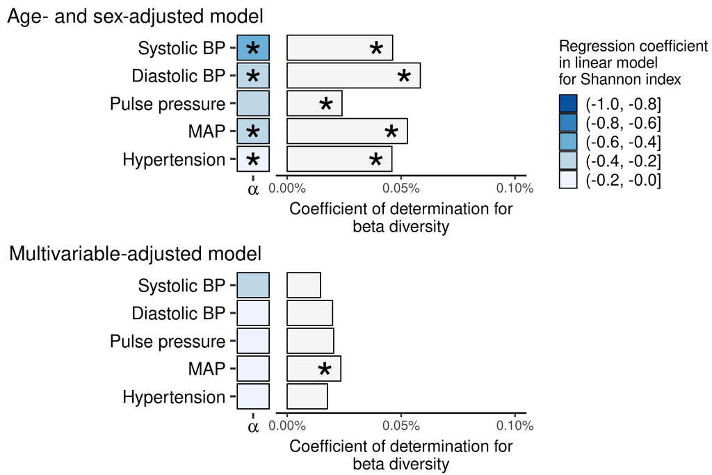

## 7.3 Principal coordinate analysis

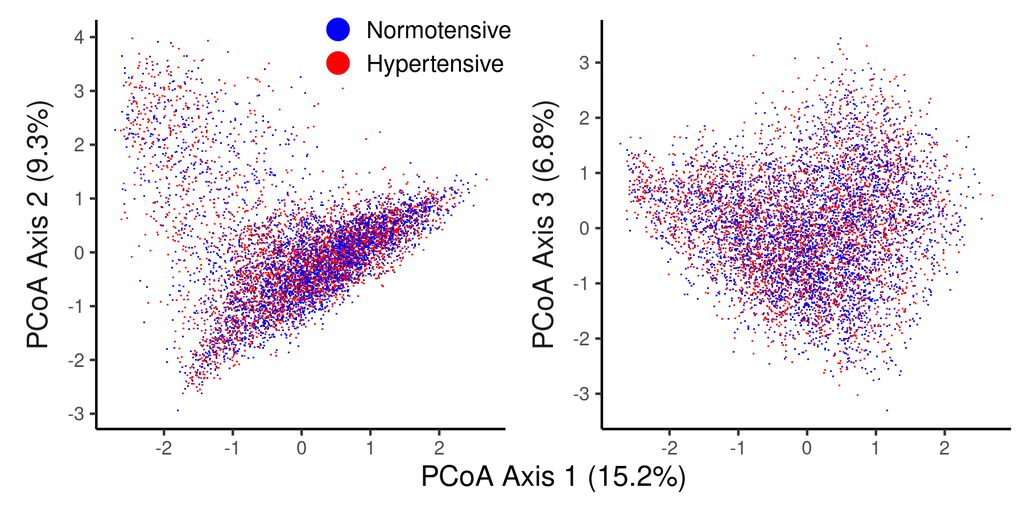

## 7.4 Associations for genera

```r
dset.deseq.signf <- deseqresults(dds, names.dset)
g.deseq <- deseqheatmap(dset.deseq.signf)
```

Significant associations found between blood pressure indices and N:o 122 genera and N:o 46 features. N:o 82 positive associations found.

### 7.4.1 Associations for hypertension looping covariates

```r
deseqresults(dds3, names.dset, hypertensionvars = names(dds3)) %>%
    select(Name, Feature, log2FoldChange) %>%
    spread(Name, log2FoldChange) %>%
    kable
```

| Feature | Age | Beta blockers | BMI | CCBs | Diabetes | Diuretics | Exercise | RAS inhibitors | Smoking |
| --- | --- | --- | --- | --- | --- | --- | --- | --- | --- |
| Actinomyces | 0.1008496 | 0.1184856 | 0.0765614 | 0.0935246 | 0.0994138 | 0.1002009 | 0.0915312 | 0.1142122 | 0.1007467 |
| Akkermansia | -0.2260576 |  |  | -0.2205125 | -0.2434912 |  |  | -0.2072151 | -0.2283885 |
| Alistipes | -0.0878970 | -0.1050958 |  | -0.0875489 |  |  | -0.0882167 | -0.0949410 | -0.0903443 |
| Alloprevotella |  | -0.0934835 | -0.1040558 |  |  |  |  | -0.1005984 |  |
| Anaerostipes | 0.2480527 | 0.2148099 | 0.1855734 | 0.2526717 | 0.2479414 | 0.2291466 | 0.2433758 | 0.2322716 | 0.2566587 |
| Anaerotruncus | -0.0710110 | -0.0808592 |  | -0.0852947 | -0.0806539 | -0.0690163 | -0.0742235 | -0.0814847 | -0.0689663 |
| Bacteroides | 0.0967260 |  |  | 0.1041330 | 0.0863298 |  | 0.0888149 |  | 0.0978382 |
| Bifidobacterium |  | 0.1268126 |  |  |  |  |  | 0.1174278 |  |
| Blautia | 0.1875118 | 0.1721346 | 0.1333126 | 0.1857403 | 0.1839788 | 0.1719256 | 0.1799449 | 0.1693268 | 0.1907131 |
| Butyricicoccus | -0.0659803 | -0.0608294 |  | -0.0632506 | -0.0673773 | -0.0644581 | -0.0671117 | -0.0687960 | -0.0585515 |
| Butyrivibrio | -0.2203714 |  |  | -0.2201355 | -0.1942749 | -0.2019374 | -0.2023111 | -0.1832659 | -0.2076072 |
| Catenibacterium |  |  | -0.2518664 |  |  |  |  |  |  |
| Cellulomonas |  |  |  | 0.1622386 |  |  |  | 0.1718001 |  |
| Citrobacter |  | 0.2540532 |  | 0.2346504 |  | 0.2129486 |  |  |  |
| Clostridioides |  |  |  | 0.0869938 |  |  |  |  |  |
| Collinsella | 0.2299005 | 0.2722522 | 0.1346674 | 0.2329886 | 0.2238439 | 0.2309369 | 0.2109593 | 0.2523239 | 0.2368414 |
| Coprobacillus | -0.1466989 | -0.1464503 | -0.1376318 | -0.1501633 | -0.1597622 | -0.2081308 | -0.1589034 | -0.1539795 | -0.1428872 |
| Coprobacter | 0.1012976 |  |  | 0.1161417 |  | 0.1035276 |  |  | 0.0986102 |
| Coprococcus | 0.1247468 | 0.1269587 | 0.0981762 | 0.1192474 | 0.1251640 | 0.1279470 | 0.1256461 | 0.1226287 | 0.1238229 |
| Dialister | 0.1782370 | 0.2268243 |  | 0.1947438 |  |  | 0.1781468 | 0.1877075 | 0.1743320 |
| Dielma | 0.4397496 | 0.3171104 | 0.4816210 | 0.4545457 | 0.2708488 | 0.4324852 | 0.4425223 | 0.3476688 | 0.4465281 |
| Dorea | 0.1312757 | 0.1356266 |  | 0.1395115 | 0.1362832 | 0.1353734 | 0.1317867 | 0.1446154 | 0.1307656 |
| Eisenbergiella | 0.1836364 |  | 0.2430192 | 0.1499201 |  | 0.1825527 | 0.2079857 | 0.1834632 | 0.1854359 |
| Enorma |  | 0.2229085 | 0.1520384 |  | 0.1036741 | 0.1280899 |  |  |  |
| Enterobacter | 0.8642222 | 0.9353544 | 1.0874312 | 0.8344913 | 0.8662768 | 0.8924398 | 0.8816316 | 0.8639431 | 0.7826091 |
| Erysipelatoclostridium | 0.2681181 | 0.1899901 | 0.3172440 | 0.2557429 | 0.2470229 | 0.2129046 | 0.2386716 | 0.1813232 | 0.2579307 |
| Eubacterium | 0.0496695 |  |  | 0.0560800 | 0.0512058 |  | 0.0521519 |  |  |
| Faecalicoccus |  | -0.1159423 |  |  |  | -0.1008745 |  | -0.0925156 |  |
| Faecalitalea |  |  | 0.0900610 |  |  |  |  |  | 0.0825267 |
| Fournierella | -0.0768041 | -0.0888756 | -0.0413918 | -0.0824548 | -0.0782568 | -0.0811820 | -0.0789186 | -0.0877595 | -0.0745814 |
| Holdemania | 0.2177189 | 0.1453773 | 0.2535882 | 0.2295689 | 0.2169100 | 0.2137401 | 0.2008954 | 0.2271651 | 0.2189734 |
| Hungatella | 0.1315428 | 0.0886491 |  | 0.1364182 |  | 0.1213208 | 0.1421972 | 0.0902676 | 0.1245629 |
| Intestinibacter | 0.2048051 | 0.2370036 | 0.1388924 | 0.2319646 | 0.2232463 | 0.1854609 | 0.1911312 | 0.2203833 | 0.1906647 |
| Johnsonella | -0.0505454 |  |  |  |  | -0.0504634 |  |  | -0.0530381 |
| Kluyvera | 0.5800314 | 0.5168483 | 0.6649744 | 0.6010347 | 0.4491408 | 0.6247957 |  | 0.5903878 | 0.5276662 |
| Lactobacillus | -0.9540617 | -0.9031887 | -1.0351880 | -0.9492738 |  | -0.9969867 |  | -0.9040694 |  |
| Lactococcus |  | 0.2081027 |  | 0.1592081 |  |  |  |  |  |
| Megasphaera | 0.4048730 | 0.5300264 |  | 0.4239518 | 0.3802902 | 0.4322918 | 0.3119722 | 0.4443432 | 0.3939630 |
| Odoribacter | -0.1161899 | -0.1254315 |  | -0.1101453 | -0.1214463 | -0.1256804 | -0.1135174 | -0.1214028 | -0.1180986 |
| Paraprevotella |  | 0.1652746 |  |  |  | 0.1608759 |  | 0.1508407 | 0.1549819 |
| Phascolarctobacterium | 0.3327029 | 0.3131917 | 0.2310770 | 0.3251220 | 0.3341079 | 0.3314415 | 0.3165636 | 0.3141830 | 0.3346375 |
| Roseburia | 0.0805931 | 0.0813554 |  | 0.0874521 | 0.0796325 | 0.0820772 | 0.0807598 | 0.0873048 | 0.0816696 |
| Ruminiclostridium | -0.1122172 | -0.1323594 |  | -0.1237916 | -0.1150556 | -0.1117866 | -0.1079369 | -0.1426467 | -0.1115363 |
| Ruthenibacterium | 0.1850870 |  | 0.2362480 | 0.1580356 | 0.1700854 | 0.1793884 | 0.1587155 | 0.1790292 | 0.1790359 |
| Sellimonas | 0.2780285 | 0.2610424 | 0.2816765 | 0.2619996 | 0.2609533 |  | 0.2596520 | 0.3074600 | 0.2717390 |
| Senegalimassilia | -0.1859039 | -0.1418809 | -0.2329189 | -0.1801106 | -0.1806729 | -0.1769527 | -0.1872787 | -0.1842586 | -0.1800057 |
| Sutterella | 0.1824251 |  |  | 0.2000109 | 0.1829173 | 0.1969771 | 0.1826489 | 0.2136478 | 0.1913702 |
| Tyzzerella | 0.1505618 | 0.1633322 | 0.1745334 | 0.1641243 | 0.1508553 | 0.1482438 | 0.1342295 |  | 0.1657784 |
| Veillonella |  |  | 0.5164674 |  |  |  | 0.5460590 |  |  |

## 7.5 Associations for Lactobacillus species

```r
dset.deseq.signf.na <- deseqresults(ddsNa, names.dset)
g.deseq.na <- deseqheatmap(dset.deseq.signf.na)
```

Significant associations found between blood pressure indices and N:o 41 genera and N:o 19 features. N:o 12 positive associations found.

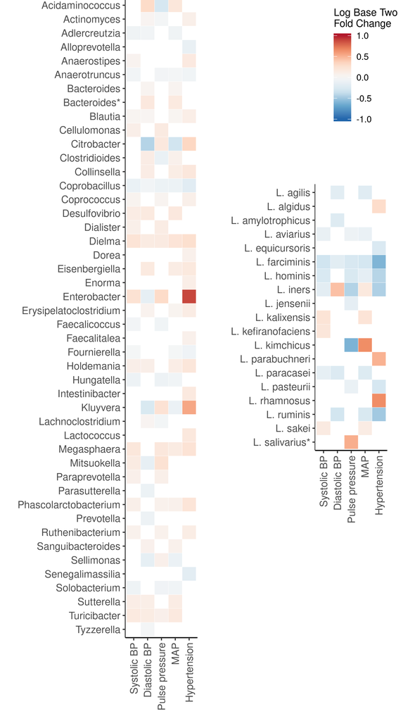

## 7.6 Salt subset

## 7.7 Association between genera and dU-NA

```r
dds.salt <- myDESeq(pseq = pseq.genus,
                    coretaxa = pseq.genus.coretaxa,
                    vars = c("NA.", var.CL),
                    saltsubset = TRUE)
pseq.genus.salt <- pseqsubset(pseq.genus, coretaxa = pseq.genus.coretaxa, saltsubset = TRUE)
```

Lactobacillus prevalence in subsample 15.4%.

```r
dds.salt %>%
    results(., name = "NA.", tidy = TRUE) %>%
    dplyr::mutate(qval = p.adjust(pvalue, method="BH")) %>%
    filter(row == "Lactobacillus (Bacteria)") %>%
    kable
```

| row | baseMean | log2FoldChange | lfcSE | stat | pvalue | padj | qval |
| --- | --- | --- | --- | --- | --- | --- | --- |
| Lactobacillus (Bacteria) | 893.0655 | 0.0100854 | 0.0022612 | 4.460253 | 8.2e-06 | 0.0003888 | 0.0003888 |

Graphical representation for findings

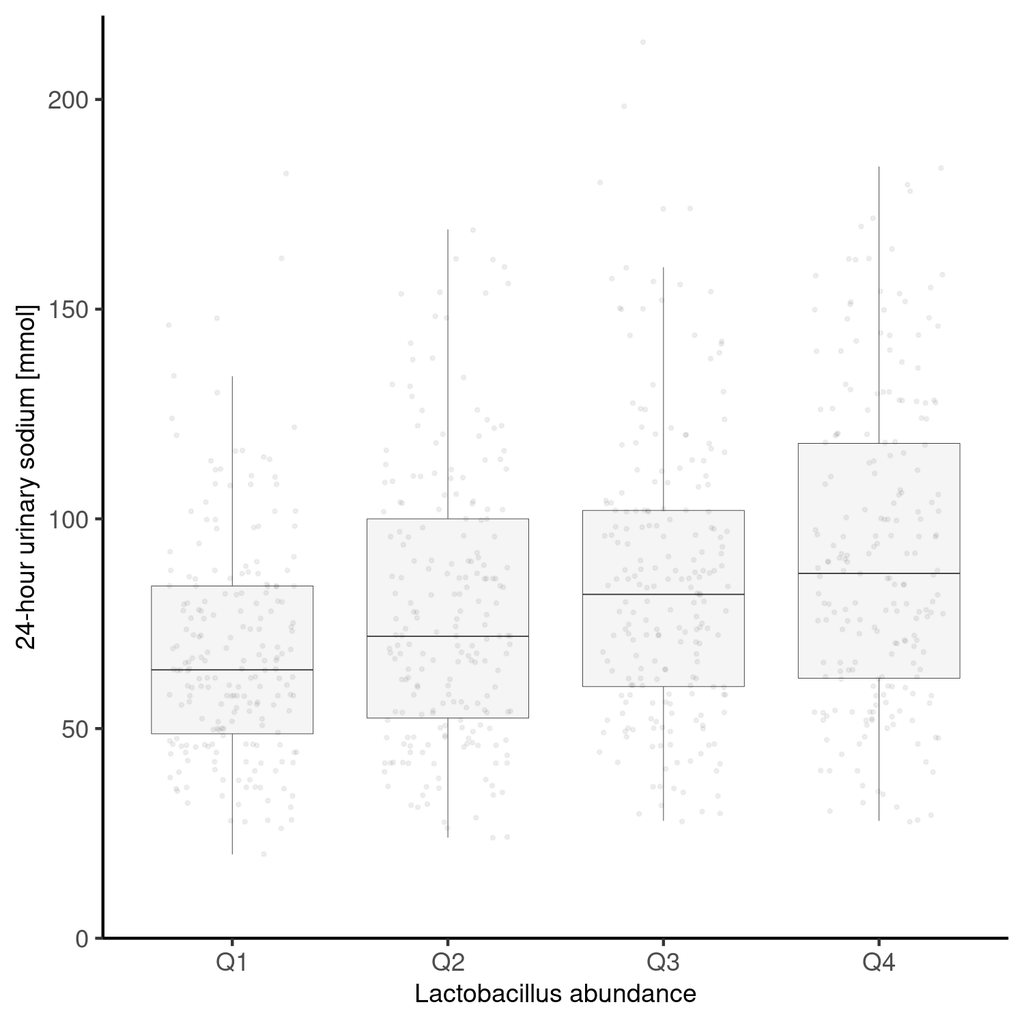

## 7.8 Association between Lactobacilli and dU-NA

```r
dds.salt.species <- myDESeq(pseq = pseq.species,
                        vars = c("NA.", var.CL),
                        coreterm = "^Lactobacillus.*Bacteria",
                        saltsubset = TRUE)
```

Significant results after FDR correction

```r
dds.salt.species %>%
    results(., name = "NA.", tidy = TRUE) %>%
    dplyr::mutate(qval = p.adjust(pvalue, method="BH"),
                  row = renametaxa(row)) %>%
    filter(qval < 0.05) %>%
    kable
```

| row | baseMean | log2FoldChange | lfcSE | stat | pvalue | padj | qval |
| --- | --- | --- | --- | --- | --- | --- | --- |
| L. sakei | 3.714017 | 0.0150131 | 0.0032198 | 4.662684 | 3.10e-06 | 0.0004619 | 0.0004619 |
| L. salivarius | 11.997755 | 0.0128521 | 0.0030510 | 4.212392 | 2.53e-05 | 0.0018698 | 0.0018698 |

# 8 Supplements

Listing our “core” genera

```r
core.names.incols <- pseq.genus.coretaxa %>%
    renametaxa %>%
    sort %>%
    list.partition %>%
    mycbind %>%
    as.data.frame

core.names.flextable <- flextable(core.names.incols) %>%
    flextable::fontsize(size = 10, part = "header") %>%
    flextable::fontsize(size = 10, part = "body") %>%
    flextable::width(j=1:3, width = 1.8) %>%
    flextable::align(align = "left", part = "header") %>%
    flextable::align(align = "left")

core.names.flextable
```

| 0 | 1 | 2 |
| --- | --- | --- |
| Acetivibrio | Dielma | Marvinbryantia |
| Acidaminococcus | Dorea | Megamonas |
| Actinomyces | Eggerthella | Megasphaera |
| Adlercreutzia | Eisenbergiella | Methanobrevibacter |
| Akkermansia | Enorma | Methanomassiliicoccus |
| Alistipes | Enterobacter | Mitsuokella |
| Alloprevotella | Enterococcus | Odoribacter |
| Anaerostipes | Erysipelatoclostridium | Oscillibacter |
| Anaerotruncus | Escherichia | Parabacteroides |
| Bacteroides | Escherichia* | Paraprevotella |
| Bacteroides* | Eubacterium | Parasutterella |
| Barnesiella | Eubacterium* | Phascolarctobacterium |
| Bifidobacterium | Faecalibacterium | Phocea |
| Bilophila | Faecalicatena | Porphyromonas |
| Bittarella | Faecalicoccus | Prevotella |
| Blautia | Faecalitalea | Roseburia |
| Butyricicoccus | Fournierella | Ruminiclostridium |
| Butyricimonas | Gordonibacter | Ruminococcus |
| Butyrivibrio | Haemophilus | Ruthenibacterium |
| Catenibacterium | Halapricum | Sanguibacteroides |
| Caudovirales | Holdemanella | Sellimonas |
| Cellulomonas | Holdemania | Senegalimassilia |
| Citrobacter | Hungatella | Shigella |
| Clostridioides | Intestinibacter | Solobacterium |
| Clostridium | Johnsonella | Streptococcus |
| Collinsella | Klebsiella | Subdoligranulum |
| Coprobacillus | Klebsiella* | Sutterella |
| Coprobacter | Kluyvera | Tannerella |
| Coprococcus | Lachnoanaerobaculum | Turicibacter |
| Dakarella | Lachnoclostridium | Tyzzerella |
| Desulfovibrio | Lactobacillus | Veillonella |
| Dialister | Lactococcus |  |

Listing results for alpha diversity

```r
alphadiversity.table <- diversity %>% map_df(~as.data.frame(.x), .id = "model") %>%
    mutate(mean_ci = sprintf("%.2f (%.2f - %.2f)", alpha.effect, alpha.low, alpha.high),
           pubp = pub.p(alpha.p)) %>%
    myspread(list = c2l("mean_ci", "pubp"), term = "Name", key = "model") %>%
    arrange(match(Name, c("Systolic BP", "Diastolic BP", "Mean arterial pressure", "Pulse pressure", "Hypertension"))) %>%
        select(Name, min_mean_ci, min_pubp, max_mean_ci, max_pubp)

typology.tbls2 <- data.frame(
    col_keys = colnames(alphadiversity.table),
    what = c("", rep("Age- and sex adjusted model", 2), rep("Multivaraible adjusted model", 2)),
    measure = c("", rep(c("beta (95%-CI)", "p"), 2)),
    stringsAsFactors = FALSE)

alphadiversity.flextable <-
    typologyformatter(data = alphadiversity.table, font = 12, typology = typology.tbls2) %>%
    flextable::width(j=1, width = 1.9) %>%
    flextable::width(j=c(2:2,4:4), width = 1.8) %>%
    flextable::width(j=c(3:3,5:5), width = 0.7)
alphadiversity.flextable
```

|  | Age- and sex adjusted model beta (95%-CI) | Age- and sex adjusted model p | Multivaraible adjusted model beta (95%-CI) | Multivaraible adjusted model p |
| --- | --- | --- | --- | --- |
| Systolic BP | -0.54 (-0.96 - -0.12) | 0.01 | -0.20 (-0.62 - 0.21) | 0.33 |
| Diastolic BP | -0.31 (-0.56 - -0.06) | 0.02 | -0.10 (-0.35 - 0.14) | 0.40 |
| Pulse pressure | -0.23 (-0.59 - 0.13) | 0.20 | -0.10 (-0.46 - 0.26) | 0.58 |
| Hypertension | 0.91 (0.86 - 0.96) | <0.001 | 0.98 (0.92 - 1.04) | 0.50 |
| MAP | -0.39 (-0.66 - -0.12) | 0.005 | -0.14 (-0.40 - 0.12) | 0.30 |

```r
betadiversity.table <- diversity %>% map_df(~as.data.frame(.x), .id = "model") %>%
    mutate(rsquared = sprintf("%.3f%%", beta.R2*100),
           pubp = pub.p(beta.p)) %>%
    myspread(list = c2l("rsquared", "pubp"), term = "Name", key = "model") %>%
    arrange(match(Name, c("Systolic BP", "Diastolic BP", "Mean arterial pressure", "Pulse pressure", "Hypertension"))) %>%
    select(Name, min_rsquared, min_pubp, max_rsquared, max_pubp)

typology.tbls3 <- data.frame(
    col_keys = colnames(betadiversity.table),
    what = c("", rep("Age- and sex adjusted model", 2), rep("Multivaraible adjusted model", 2)),
    measure = c("", rep(c("R2", "p"), 2)),
    stringsAsFactors = FALSE)

betadiversity.flextable <-
    typologyformatter(data = betadiversity.table, font = 12, typology = typology.tbls3) %>%
    flextable::width(j=1, width = 1.9) %>%
    flextable::width(j=c(2:5), width = 0.8)

betadiversity.flextable
```

|  | Age- and sex adjusted model R2 | Age- and sex adjusted model p | Multivaraible adjusted model R2 | Multivaraible adjusted model p |
| --- | --- | --- | --- | --- |
| Systolic BP | 0.046% | 0.001 | 0.018% | 0.20 |
| Diastolic BP | 0.053% | 0.001 | 0.024% | 0.03 |
| Pulse pressure | 0.024% | 0.04 | 0.020% | 0.09 |
| Hypertension | 0.046% | 0.002 | 0.015% | 0.38 |
| MAP | 0.058% | 0.001 | 0.020% | 0.13 |

```r
deseq.table <- dset.deseq.signf %>%
    mutate(lfc_se = sprintf("%.2f±%.2f", log2FoldChange, lfcSE),
           p.value = pub.p(qval)) %>%
    myspread %>%
    select(Feature, starts_with("Systolic"), starts_with("Diastolic"), starts_with("Pulse pressure"),
           starts_with("MAP"), starts_with("Hypertension"))

typology.deseq <- data.frame(
    col_keys = colnames(deseq.table),
    what = c("", rep("Systolic BP", 2), rep("Diastolic BP", 2),
             rep("Pulse pressure", 2), rep("Mean arterial pressure", 2), rep("Hypertension", 2)),
    measure = c("", rep(c("Log2FC±SE", "p"), 5)),
    stringsAsFactors = FALSE)


typologyformatter(data = deseq.table, font = 9, typology = typology.deseq) %>%
    flextable::width(j = 1, width = 1.2) %>%
    flextable::width(j = seq(2, 11, 2), width = 0.75) %>%
    flextable::width(j = seq(3, 11, 2), width = 0.55)
```

|  | Systolic BP Log2FC±SE | Systolic BP p | Diastolic BP Log2FC±SE | Diastolic BP p | Pulse pressure Log2FC±SE | Pulse pressure p | Mean arterial pressure Log2FC±SE | Mean arterial pressure p | Hypertension Log2FC±SE | Hypertension p |
| --- | --- | --- | --- | --- | --- | --- | --- | --- | --- | --- |
| Acidaminococcus |  |  | 0.32±0.04 | <0.001 | -0.29±0.04 | <0.001 | 0.20±0.04 | <0.001 |  |  |
| Actinomyces |  |  | 0.04±0.01 | 0.01 | -0.03±0.01 | 0.04 |  |  | 0.10±0.03 | 0.008 |
| Adlercreutzia | -0.07±0.02 | 0.008 | -0.06±0.02 | 0.04 |  |  | -0.07±0.02 | 0.006 |  |  |
| Alloprevotella |  |  |  |  |  |  |  |  | -0.12±0.04 | 0.006 |
| Anaerostipes | 0.06±0.02 | 0.01 |  |  |  |  |  |  | 0.16±0.04 | <0.001 |
| Anaerotruncus | -0.05±0.01 | <0.001 |  |  | -0.05±0.01 | <0.001 | -0.03±0.01 | 0.010 | -0.06±0.02 | 0.04 |
| Bacteroides |  |  | 0.05±0.02 | 0.03 |  |  | 0.05±0.02 | 0.02 |  |  |
| Bacteroides* |  |  | 0.17±0.04 | <0.001 |  |  | 0.16±0.04 | <0.001 |  |  |
| Blautia | 0.04±0.01 | 0.01 | 0.03±0.01 | 0.04 |  |  | 0.04±0.01 | 0.008 | 0.11±0.03 | <0.001 |
| Cellulomonas | 0.10±0.03 | 0.02 |  |  | 0.15±0.03 | <0.001 |  |  |  |  |
| Citrobacter |  |  | -0.43±0.04 | <0.001 | 0.17±0.04 | <0.001 | -0.33±0.04 | <0.001 | 0.35±0.10 | 0.002 |
| Clostridioides |  |  | 0.13±0.02 | <0.001 | -0.12±0.02 | <0.001 | 0.09±0.02 | <0.001 |  |  |
| Collinsella |  |  | 0.13±0.02 | <0.001 |  |  | 0.12±0.02 | <0.001 | 0.19±0.05 | 0.002 |
| Coprobacillus | -0.12±0.02 | <0.001 | -0.06±0.02 | 0.006 | -0.10±0.02 | <0.001 | -0.10±0.02 | <0.001 | -0.20±0.04 | <0.001 |
| Coprococcus | 0.05±0.01 | 0.004 |  |  | 0.05±0.01 | 0.004 |  |  | 0.10±0.03 | 0.01 |
| Desulfovibrio | 0.13±0.03 | <0.001 | 0.16±0.03 | <0.001 |  |  | 0.17±0.03 | <0.001 |  |  |
| Dialister | 0.10±0.04 | 0.04 |  |  | 0.13±0.04 | 0.002 |  |  |  |  |
| Dielma | 0.23±0.03 | <0.001 | 0.14±0.03 | <0.001 | 0.15±0.03 | <0.001 | 0.22±0.03 | <0.001 | 0.28±0.07 | 0.001 |
| Dorea |  |  |  |  |  |  |  |  | 0.08±0.03 | 0.03 |
| Eisenbergiella |  |  | 0.16±0.03 | <0.001 |  |  | 0.13±0.03 | <0.001 | 0.17±0.06 | 0.02 |
| Enorma |  |  |  |  |  |  |  |  | 0.11±0.04 | 0.05 |
| Enterobacter | 0.25±0.04 | <0.001 | -0.15±0.04 | <0.001 | 0.32±0.04 | <0.001 |  |  | 0.89±0.09 | <0.001 |
| Erysipelatoclostridium |  |  | 0.06±0.02 | 0.006 |  |  | 0.05±0.02 | 0.03 | 0.13±0.04 | 0.01 |
| Faecalicoccus | -0.05±0.02 | 0.04 |  |  | -0.06±0.02 | 0.003 |  |  |  |  |
| Faecalitalea |  |  |  |  |  |  |  |  | 0.08±0.03 | 0.05 |
| Fournierella | -0.02±0.01 | 0.02 |  |  |  |  | -0.03±0.01 | 0.01 | -0.07±0.02 | 0.002 |
| Holdemania | 0.10±0.02 | <0.001 | 0.10±0.02 | <0.001 |  |  | 0.12±0.02 | <0.001 | 0.20±0.04 | <0.001 |
| Hungatella | -0.09±0.02 | <0.001 |  |  | -0.09±0.02 | <0.001 | -0.06±0.02 | 0.006 |  |  |
| Intestinibacter |  |  |  |  |  |  |  |  | 0.17±0.06 | 0.03 |
| Kluyvera |  |  | -0.26±0.04 | <0.001 | 0.24±0.04 | <0.001 | -0.11±0.04 | 0.05 | 0.55±0.09 | <0.001 |
| Lachnoclostridium |  |  | 0.04±0.01 | 0.008 | -0.04±0.01 | 0.005 |  |  |  |  |
| Lactococcus |  |  |  |  |  |  |  |  | 0.18±0.07 | 0.05 |
| Megasphaera | 0.19±0.03 | <0.001 |  |  | 0.19±0.03 | <0.001 | 0.14±0.03 | <0.001 | 0.23±0.07 | 0.008 |
| Mitsuokella | 0.15±0.04 | 0.001 | -0.14±0.04 | 0.001 | 0.25±0.04 | <0.001 |  |  |  |  |
| Paraprevotella | 0.09±0.03 | 0.02 |  |  | 0.10±0.03 | 0.005 |  |  |  |  |
| Parasutterella |  |  | -0.10±0.04 | 0.03 |  |  |  |  |  |  |
| Phascolarctobacterium | 0.10±0.03 | 0.01 |  |  | 0.08±0.03 | 0.04 | 0.08±0.03 | 0.04 | 0.22±0.07 | 0.007 |
| Prevotella |  |  | -0.09±0.03 | 0.05 |  |  |  |  |  |  |
| Ruthenibacterium | 0.07±0.02 | 0.004 |  |  | 0.08±0.02 | 0.001 |  |  | 0.12±0.05 | 0.03 |
| Sanguibacteroides |  |  | 0.08±0.02 | 0.005 |  |  | 0.08±0.02 | 0.006 |  |  |
| Sellimonas |  |  | -0.15±0.02 | <0.001 | 0.09±0.02 | <0.001 | -0.10±0.02 | <0.001 |  |  |
| Senegalimassilia |  |  |  |  |  |  |  |  | -0.18±0.05 | 0.003 |
| Solobacterium | -0.08±0.02 | 0.001 |  |  | -0.07±0.02 | 0.005 | -0.06±0.02 | 0.01 |  |  |
| Sutterella | 0.11±0.04 | 0.010 | 0.11±0.03 | 0.008 |  |  | 0.13±0.04 | 0.002 |  |  |
| Turicibacter | 0.16±0.04 | <0.001 | 0.13±0.03 | <0.001 | 0.09±0.03 | 0.03 | 0.17±0.04 | <0.001 |  |  |
| Tyzzerella |  |  | -0.04±0.01 | 0.03 |  |  |  |  |  |  |

```r
deseq.table.na <- dset.deseq.signf.na %>%
    mutate(lfc_se = sprintf("%.2f±%.2f", log2FoldChange, lfcSE),
           p.value = pub.p(qval)) %>%
    myspread %>%
    select(Feature, starts_with("Systolic"), starts_with("Diastolic"), starts_with("Pulse pressure"),
           starts_with("MAP"), starts_with("Hypertension"))

typologyformatter(data = deseq.table.na, font = 9, typology = typology.deseq) %>%
    flextable::width(j = 1, width = 1.2) %>%
    flextable::width(j = seq(2, 11, 2), width = 0.75) %>%
    flextable::width(j = seq(3, 11, 2), width = 0.55)
```

|  | Systolic BP Log2FC±SE | Systolic BP p | Diastolic BP Log2FC±SE | Diastolic BP p | Pulse pressure Log2FC±SE | Pulse pressure p | Mean arterial pressure Log2FC±SE | Mean arterial pressure p | Hypertension Log2FC±SE | Hypertension p |
| --- | --- | --- | --- | --- | --- | --- | --- | --- | --- | --- |
| L. agilis |  |  | -0.19±0.06 | 0.02 |  |  | -0.20±0.06 | 0.01 |  |  |
| L. algidus |  |  |  |  |  |  |  |  | 0.30±0.09 | 0.01 |
| L. amylotrophicus |  |  | -0.22±0.06 | 0.003 |  |  |  |  |  |  |
| L. aviarius | -0.13±0.03 | 0.001 |  |  | -0.09±0.03 | 0.04 | -0.12±0.03 | 0.003 |  |  |
| L. equicursoris |  |  |  |  |  |  |  |  | -0.25±0.07 | 0.003 |
| L. farciminis | -0.33±0.05 | <0.001 | -0.19±0.04 | <0.001 | -0.27±0.04 | <0.001 | -0.30±0.05 | <0.001 | -0.60±0.10 | <0.001 |
| L. hominis | -0.26±0.04 | <0.001 |  |  | -0.27±0.04 | <0.001 | -0.16±0.04 | 0.003 | -0.42±0.09 | <0.001 |
| L. iners | -0.18±0.05 | 0.01 | 0.44±0.05 | <0.001 | -0.43±0.05 | <0.001 | 0.17±0.05 | 0.02 | -0.45±0.11 | 0.001 |
| L. jensenii |  |  |  |  | -0.16±0.05 | 0.01 |  |  |  |  |
| L. kalixensis | 0.23±0.07 | 0.01 |  |  |  |  | 0.22±0.06 | 0.01 |  |  |
| L. kefiranofaciens | 0.20±0.06 | 0.02 |  |  |  |  |  |  |  |  |
| L. kimchicus |  |  |  |  | -0.61±0.19 | 0.03 | 0.65±0.20 | 0.02 |  |  |
| L. parabuchneri |  |  |  |  |  |  |  |  | 0.50±0.15 | 0.02 |
| L. paracasei | -0.15±0.04 | 0.02 | -0.23±0.04 | <0.001 |  |  | -0.23±0.04 | <0.001 |  |  |
| L. pasteurii |  |  |  |  | -0.12±0.03 | <0.001 |  |  | -0.29±0.06 | <0.001 |
| L. rhamnosus |  |  |  |  |  |  |  |  | 0.65±0.12 | <0.001 |
| L. ruminis |  |  | -0.32±0.04 | <0.001 |  |  | -0.26±0.04 | <0.001 | -0.49±0.08 | <0.001 |
| L. sakei | 0.15±0.04 | 0.009 |  |  |  |  | 0.13±0.04 | 0.04 |  |  |
| L. salivarius* |  |  |  |  | 0.52±0.11 | <0.001 |  |  |  |  |

```r
save.image(file = paste0("session/session-", now, ".Rdata"))
```